# Chapter 4, Part 1: Introduction to Forecasting

Machine Learning

Author

Affiliation

F.San Segundo & V.Varo

Based on notes by Professors A.Muñoz, J.Portela & J.Pizarroso

Published

March 2024

# Chapter 4, Part 1: Introduction to Forecasting

**Recommended reading:**

See References section at the end for details.

# Session Setup

**Libraries**

Let us begin by loading the libraries we will use.

```python
### Load necessary modules -------------------------------
# interactive plotting
# %matplotlib inline
%config InlineBackend.figure_format = 'png' # ‘png’, ‘retina’, ‘jpeg’, ‘svg’, ‘pdf’
%matplotlib inline

import numpy as np
import pandas as pd
import scipy.stats as stats
import seaborn as sns
import matplotlib.pyplot as plt
sns.set()
import statsmodels.api as sm


# # Data management libraries

# # Machine learning libraries
# from sklearn.model_selection import train_test_split, cross_val_score
# from sklearn.pipeline import Pipeline
# from sklearn.metrics import mean_squared_error
# from sklearn.linear_model import LinearRegression
# from sklearn.feature_selection import SequentialFeatureSelector


# others
# import math
# from mltools import classification_tools as CT
# from mltools import model_tools as MT
# from statsmodels.stats import contingency_tables as cont_tab
# from statsmodels.stats.outliers_influence import variance_inflation_factor
# import warnings

# from sklearn2pmml.statsmodels import StatsModelsRegressor
# from sklego.preprocessing import PatsyTransformer
# from statsmodels.api import OLS
# import patsy as ps
# ############################################
# ### Load libraries ###

# interactive plotting

# # plotting libraries
# import seaborn as sns
# import matplotlib.pyplot as plt
# sns.set()

# # Data management libraries
# import numpy as np # linear algebra
# import pandas as pd # data processing, CSV file I/O (e.g. pd.read_csv)

# # Machine learning libraries
# from sklearn.feature_selection import RFECV
# from sklearn.model_selection import train_test_split, GridSearchCV, cross_val_score
# from sklearn.linear_model import Ridge, Lasso, ElasticNet
# from sklearn.decomposition import PCA
# from sklearn.cross_decomposition import PLSRegression
# from sklearn.pipeline import Pipeline
# from sklearn.preprocessing import StandardScaler, OneHotEncoder, PolynomialFeatures
# from statsmodels.stats.outliers_influence import variance_inflation_factor
# from sklearn.compose import ColumnTransformer
# from sklearn.metrics import mean_squared_error, r2_score, mean_absolute_error
# from sklearn.neighbors import KNeighborsRegressor
# from sklearn.tree import DecisionTreeRegressor, plot_tree
# from sklearn.neural_network import MLPRegressor


# from sklearn import set_config
# set_config(display='diagram')

# # others
# from mltools import regression_tools as RT
# from mltools.regression_tools import LinearRegressor
# from mltools import model_tools as MT
# import math


# from sktime.datasets import load_airline
# from sktime.utils.plotting import plot_series

# Machine Learning libraries
from statsmodels.tsa.seasonal import seasonal_decompose, STL
```

```python
import sys
sys.path.insert(0, '.')
from utils import *
```

```python
plt.rc('axes', titlesize='medium')
plt.rc('axes', titlelocation='left')
plt.rc('axes.spines', right=False)
plt.rc('axes.spines', top=False)
sizets = (8,4.5)
plt.rc('figure', figsize=sizets)
```

# General Concepts about Forecasting and Time Series

**Forecasting Terminology**

A **forecast** is the prediction of some future event. Forecasting problems are classified as:

- *Short-term:* a few time periods (days, weeks, months) into the future
- *Medium-term:* from one to two years into the future
- *Long-term:* many years

Short and medium term forecasting are tipically based on identifying, modeling and extrapolating the patterns found in historical data. Long term forecasting is usually based on expert knowledge and fundamental models.

A (basic, one dimensional) **time series** is a set of data points (numbers) ordered in time:
$$y_1, y_2, \ldots, y_{t-1}, y_t,\ldots$$

# Examples of Time Series. Date Operations with Pandas

**Time Series Examples Collection**

The `data` subfolder of this session contains a collection of frequently used time series examples.

**Exercise 001**

Explore the folder: using a text editor open some of the csv files it contains and try to get a feeling of the typical structure of these examples.

**Monthly Canadian gas production, billions of cubic metres, January 1960 - February 2005**

The first example we will examine is this dataset that comes from the Rob Hyndman repository of time series at this link:

[Monthly Canadian gas production, billions of cubic metres, January 1960 - February 2005](http://pkg.robjhyndman.com/fpp3package/reference/canadian_gas.html)

The data is stored in a csv file like many we have used before, and we will read it as usual. We use `head`, `tail` and `info` to perform a first exploration.

```python
can_gas = pd.read_csv('./tsdata/fpp3/canadian_gas.csv')
can_gas.head()
```

|  | Month | Volume |
| --- | --- | --- |
| 0 | 1960 Jan | 1.4306 |
| 1 | 1960 Feb | 1.3059 |
| 2 | 1960 Mar | 1.4022 |
| 3 | 1960 Apr | 1.1699 |
| 4 | 1960 May | 1.1161 |

```python
can_gas.tail()
```

|  | Month | Volume |
| --- | --- | --- |
| 537 | 2004 Oct | 17.8268 |
| 538 | 2004 Nov | 17.8322 |
| 539 | 2004 Dec | 19.4526 |
| 540 | 2005 Jan | 19.5284 |
| 541 | 2005 Feb | 16.9441 |

```python
can_gas.info()
```

```
<class 'pandas.core.frame.DataFrame'>
RangeIndex: 542 entries, 0 to 541
Data columns (total 2 columns):
 #   Column  Non-Null Count  Dtype
---  ------  --------------  -----
 0   Month   542 non-null    object
 1   Volume  542 non-null    float64
dtypes: float64(1), object(1)
memory usage: 8.6+ KB
```

**Temporal Ordering of the Rows**

Pay special attention to the first column `Month`. In the datasets that we have used the ordering of the rows was not relevant. In fact, the observations were ucually assumed to be independent, and so permuting the rows did not affect the information in the dataset. But in a time series dataset like this, there is always a column (or columns) that describe a temporal ordering of the observations. The **row ordering is now an essential part of the dataset**. Ignoring this will ruin your analysis.

**Using `datetime` Type in Pandas**

Because of this critical role of the time ordering, and also beacuse of the complexity of the systems that we use to describe dates and time points, Pandas has a dedicated set of classes and methods to deal with temporal data. We will make an initial contact with the pandas `to_datetime` method and we will learn more about date and time operations as we go.

Our first step is to apply the method to the `Month` column and run `info` again to see the resulting change in the column. We will first create a copy of the column called `date` to keep the original date format:

```python
can_gas["Date"] = can_gas["Month"]
```

```python
can_gas["Month"] = pd.to_datetime(can_gas["Month"], format="%Y %b")
can_gas.head()
```

|  | Month | Volume | Date |
| --- | --- | --- | --- |
| 0 | 1960-01-01 | 1.4306 | 1960 Jan |
| 1 | 1960-02-01 | 1.3059 | 1960 Feb |
| 2 | 1960-03-01 | 1.4022 | 1960 Mar |
| 3 | 1960-04-01 | 1.1699 | 1960 Apr |
| 4 | 1960-05-01 | 1.1161 | 1960 May |

```python
can_gas.info()
```

```
<class 'pandas.core.frame.DataFrame'>
RangeIndex: 542 entries, 0 to 541
Data columns (total 3 columns):
 #   Column  Non-Null Count  Dtype
---  ------  --------------  -----
 0   Month   542 non-null    datetime64[ns]
 1   Volume  542 non-null    float64
 2   Date    542 non-null    object
dtypes: datetime64[ns](1), float64(1), object(1)
memory usage: 12.8+ KB
```

As you can see, pandas has transformed the column and has translated each date into the first day of the corresponding month. The type of the column is `datetime64[ns]`. This in particular means that we can perform operations such as the following. Note in particular that the results belong to two different classes, [`Timestamp`](https://pandas.pydata.org/docs/reference/api/pandas.Timestamp.html) and [`Timedelta`](https://pandas.pydata.org/docs/reference/api/pandas.Timedelta.html):

```python
can_gas["Month"].min(), can_gas["Month"].max(), can_gas["Month"][17] - can_gas["Month"][7]
```

```
(Timestamp('1960-01-01 00:00:00'),
 Timestamp('2005-02-01 00:00:00'),
 Timedelta('304 days 00:00:00'))
```

**The .dt accessor**

The [`dt` accessor](https://pandas.pydata.org/pandas-docs/version/1.5/reference/api/pandas.Series.dt.html) allows us to extract temporal information in conveninent ways from a pandas temporal object. For example, suppose we want to add a column to `can_gas` that contains the year in which the observation was made. We can do it with `dt` followed by `year` as follows:

```python
can_gas["Year"] =  can_gas["Month"].dt.year
can_gas["Year"]
```

```
0      1960
1      1960
2      1960
3      1960
4      1960
       ...
537    2004
538    2004
539    2004
540    2005
541    2005
Name: Year, Length: 542, dtype: int32
```

You can also use `dt` to get,for example, the quarter of the year, which is a frequently used measure in economical data:

```python
can_gas["Month"].dt.quarter
```

```
0      1
1      1
2      1
3      2
4      2
      ..
537    4
538    4
539    4
540    1
541    1
Name: Month, Length: 542, dtype: int32
```

**Creating a Temporal Index**

The temporal ordering of the data is so important that it is often used as the index of the dataframe, We can achieve this as follows:

```python
can_gas.set_index('Month', drop=True, inplace=True)
can_gas.head()
```

| Month | Volume | Date | Year |
| --- | --- | --- | --- |
| 1960-01-01 | 1.4306 | 1960 Jan | 1960 |
| 1960-02-01 | 1.3059 | 1960 Feb | 1960 |
| 1960-03-01 | 1.4022 | 1960 Mar | 1960 |
| 1960-04-01 | 1.1699 | 1960 Apr | 1960 |
| 1960-05-01 | 1.1161 | 1960 May | 1960 |

**Exercise 002**

What happens if you set `drop = False` here?

**A First Time Series PLot**

Usually we plot the time series with the temporal values ordered along the horizontal axis. We get this simply by calling plot. Note that the labels in the x axis (the so called *ticks*) are automatically selected in a temporal format. Take a look at the plot and look for remarkable patterns in it.

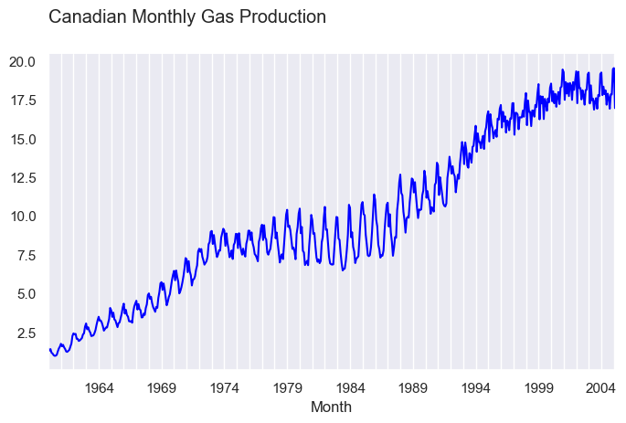

```python
fig, ax = plt.subplots()
can_gas["Volume"].plot(figsize=sizets, c="blue", ax= ax)
suptitle('Canadian Monthly Gas Production')
ax.grid(visible=True, which='Both', axis='x')
ax.grid(visible=False, which='Major', axis='y')
```

**Cherry Blossom Peak Season in Japan. Dealing with Complicated Time Periods and Missing Data.**

For our second example we consider a recently published time series about *Cherry Tree Flowering at Kyoto City* ([read more here](https://theconversation.com/social-media-snaps-map-the-sweep-of-japans-cherry-blossom-season-in-unprecedented-detail-206574)), with more than a thousand years of data going all the way back to 853 AD!

The challenge here is read the data and parse the year column, because pandas functions in a manner of speaking *find it hard to believe* that 853 is an actual year. We begin by loading the dataste which is already available in the folder for this session.

```python
cherry = pd.read_csv('./date-of-the-peak-cherry-tree-blossom-in-kyoto.csv')
cherry
```

|  | Entity | Code | Year | Twenty-year average day of the year with peak cherry blossom | Day of the year with peak cherry blossom |
| --- | --- | --- | --- | --- | --- |
| 0 | Japan | JPN | 853 | 101.000000 | 104 |
| 1 | Japan | JPN | 864 | 100.833336 | 100 |
| 2 | Japan | JPN | 866 | 101.571430 | 106 |
| 3 | Japan | JPN | 869 | 100.750000 | 95 |
| 4 | Japan | JPN | 889 | 101.111115 | 104 |
| ... | ... | ... | ... | ... | ... |
| 826 | Japan | JPN | 2019 | 95.700000 | 95 |
| 827 | Japan | JPN | 2020 | 95.300000 | 92 |
| 828 | Japan | JPN | 2021 | 94.750000 | 85 |
| 829 | Japan | JPN | 2022 | 94.750000 | 91 |
| 830 | Japan | JPN | 2023 | 94.050000 | 84 |

831 rows × 5 columns

```python
cherry.info()
```

```
<class 'pandas.core.frame.DataFrame'>
RangeIndex: 831 entries, 0 to 830
Data columns (total 5 columns):
 #   Column                                                        Non-Null Count  Dtype
---  ------                                                        --------------  -----
 0   Entity                                                        831 non-null    object
 1   Code                                                          831 non-null    object
 2   Year                                                          831 non-null    int64
 3   Twenty-year average day of the year with peak cherry blossom  831 non-null    float64
 4   Day of the year with peak cherry blossom                      831 non-null    int64
dtypes: float64(1), int64(2), object(2)
memory usage: 32.6+ KB
```

The `pd.to_datetimefunction` fails to parse the year correctly:

```python
pd.to_datetime(cherry["Year"])
```

```
0     1970-01-01 00:00:00.000000853
1     1970-01-01 00:00:00.000000864
2     1970-01-01 00:00:00.000000866
3     1970-01-01 00:00:00.000000869
4     1970-01-01 00:00:00.000000889
                   ...
826   1970-01-01 00:00:00.000002019
827   1970-01-01 00:00:00.000002020
828   1970-01-01 00:00:00.000002021
829   1970-01-01 00:00:00.000002022
830   1970-01-01 00:00:00.000002023
Name: Year, Length: 831, dtype: datetime64[ns]
```

For cases like this we can resort to the [`period` function](https://pandas.pydata.org/docs/reference/api/pandas.Period.html), that defines a more general framework for dealing with temporal data.

```python
def conv(x):
    prd = pd.Period(year=x, freq="Y")
    year_int = prd.year
    return year_int
cherry["Year"] = cherry["Year"].apply(conv)
cherry.tail()
```

|  | Entity | Code | Year | Twenty-year average day of the year with peak cherry blossom | Day of the year with peak cherry blossom |
| --- | --- | --- | --- | --- | --- |
| 826 | Japan | JPN | 2019 | 95.70 | 95 |
| 827 | Japan | JPN | 2020 | 95.30 | 92 |
| 828 | Japan | JPN | 2021 | 94.75 | 85 |
| 829 | Japan | JPN | 2022 | 94.75 | 91 |
| 830 | Japan | JPN | 2023 | 94.05 | 84 |

```python
cherry.info()
```

```
<class 'pandas.core.frame.DataFrame'>
RangeIndex: 831 entries, 0 to 830
Data columns (total 5 columns):
 #   Column                                                        Non-Null Count  Dtype
---  ------                                                        --------------  -----
 0   Entity                                                        831 non-null    object
 1   Code                                                          831 non-null    object
 2   Year                                                          831 non-null    int64
 3   Twenty-year average day of the year with peak cherry blossom  831 non-null    float64
 4   Day of the year with peak cherry blossom                      831 non-null    int64
dtypes: float64(1), int64(2), object(2)
memory usage: 32.6+ KB
```

We will rename some columns for plotting:

```python
cherry.rename(columns={'Day of the year with peak cherry blossom':'peekday',
                       'Twenty-year average day of the year with peak cherry blossom':'peekday_20yravrg'},
                       inplace=True)
```

And now we can plot the time series corresponding to the `peekday` column:

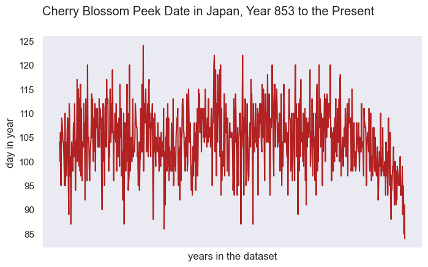

```python
ax = cherry["peekday"].plot(figsize=sizets, c="firebrick")
suptitle('Cherry Blossom Peek Date in Japan, Year 853 to the Present')
plt.tick_params(axis='x', which='both', bottom=False, top=False, labelbottom=False)
ax.set(ylabel='day in year')
ax.set(xlabel='years in the dataset')
ax.grid()
```

Do we have a complete list of years?

```python
num_years_observed = len(cherry["Year"])
years_spanned = cherry["Year"][num_years_observed - 1] - cherry["Year"][0]
print(f'''
      We have data for {num_years_observed} years, and the data span a range of {years_spanned} years.
      We have {years_spanned - num_years_observed} years missing
      ''')
```

```
      We have data for 831 years, and the data span a range of 1170 years.
      We have 339 years missing
```

These are the missing years:

```python
missing_Years = set(range(cherry["Year"].min(), cherry["Year"].max())).difference(set(cherry["Year"]))
list(missing_Years)[0:15]
```

```
[854, 855, 856, 857, 858, 859, 860, 861, 862, 863, 865, 867, 868, 870, 871]
```

In order to fill the gaps we will create a new dataset with a complete list of years. We can do that with `pd.date_range` as follows:

```python
cherry_filled = pd.DataFrame({"Year":pd.date_range(start="853-01-01", end="2023-01-01", freq="Y", unit="s")})
cherry_filled["Year"] = cherry_filled["Year"].dt.year.astype("int64")
cherry_filled.head()
```

|  | Year |
| --- | --- |
| 0 | 853 |
| 1 | 854 |
| 2 | 855 |
| 3 | 856 |
| 4 | 857 |

Now we need to fill the peekday information for those years that exist in our dataset, Those are:

```python
existing_Years = list(set(cherry_filled["Year"]).intersection(cherry["Year"]))
```

To make the filling of the new dataframe simpler we use a dictionary representation of our data.

```python
cherry_dict = {str(y):d for y, d in zip(cherry["Year"], cherry["peekday"])}
```

And we use it to fill the peekday column in the new dataset. We use `nan` for the missing years. Finally we set the year as the index of the dataframe:

```python
peekdays_filled = [cherry_dict[str(y)] if y in existing_Years else np.nan for y in cherry_filled["Year"]]
cherry_filled["peekday"] = peekdays_filled
cherry_filled["Year"] =  cherry_filled["Year"].apply(conv)
cherry_filled.set_index("Year", inplace=True)
cherry_filled
```

| Year | peekday |
| --- | --- |
| 853 | 104.0 |
| 854 | NaN |
| 855 | NaN |
| 856 | NaN |
| 857 | NaN |
| ... | ... |
| 2018 | 89.0 |
| 2019 | 95.0 |
| 2020 | 92.0 |
| 2021 | 85.0 |
| 2022 | 91.0 |

1170 rows × 1 columns

When we plot the time series you can see the gaps created by the missing years:

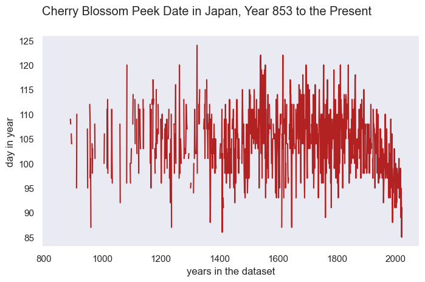

```python
ax = cherry_filled["peekday"].plot(figsize=sizets, c="firebrick")
suptitle('Cherry Blossom Peek Date in Japan, Year 853 to the Present')
ax.set(ylabel='day in year')
ax.set(xlabel='years in the dataset')
ax.grid()
```

**Imputation for Missing Data in Time Series.**

When we have missing data in a time series we can apply several different methods to *fill the gap*. Here we will use linear interpolation.

```python
cherry_filled["peekday"] = cherry_filled["peekday"].interpolate(method="linear")
```

And now the time series after imputation looks like this:

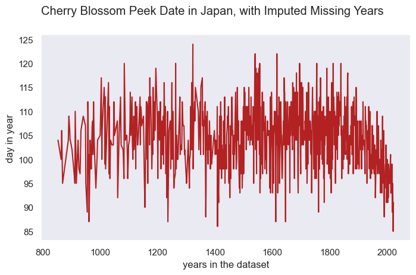

```python
ax = cherry_filled["peekday"].plot(figsize=sizets, c="firebrick")
suptitle('Cherry Blossom Peek Date in Japan, with Imputed Missing Years')
ax.set(ylabel='day in year')
ax.set(xlabel='years in the dataset')
ax.grid()
```

# Time Series Components. Trend and Seasonality.

**Time Series Components. Trend and Seasonality.**

**Trend.** Some of the time series plots in the previous examples show a general *upward* or *downward* direction when you consider the series as a whole over long periods of time. A trend is therefore a long term increase or decrease of the time series values. That is not to say that the time series is always increasing or decreasing.

**Seasonality.** Many time series take values that are affected by periodic phenomena such as the change of seasons, the day/night cycle or the weekend vs workdays common in many human activities. These cyclyc or periodic behavior is often easy to spot in the time plot of the series in the presence of an underlying pattern that repeats with a fixed frequency (hourly, daily or weekly and so on). Keep in mind however that the time series we are interested in are not deterministic. They are affected by noise terms and so these repeating patterns are not exact copies (as would be the case in a purely periodic time series in the mathematical sense).

Let us look back at the canadian gas example. Can you see trend and seasonality at play here?

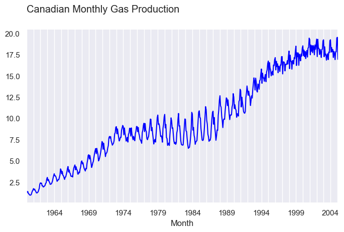

```python
fig, ax = plt.subplots()
can_gas["Volume"].plot(figsize=sizets, c="blue", ax= ax)
suptitle('Canadian Monthly Gas Production')
ax.grid(visible=True, which='Both', axis='x')
ax.grid(visible=False, which='Major', axis='y')
```

**Exercise 003**

Look at the time series in [Figure 2.3 of (Hyndman and Athanasopoulos 2021)](https://otexts.com/fpp3/tspatterns.html#fig:fourexamples) and answer if they have a visible trend or they display seasonal behavior.

**Estimating the Trend**

How can we estimate the trend of a time series? A trend in a series such as the candaina gas production means for exameple that the average value for the late 90s is higher than it was in the 60s. Therefore to investigate the trend we can thonk about **local means**. Not the total average of the time series, but a **rolling window** average that only takes into account the most recent years.

In Python we can get this kind of *windowed measures* with `rolling` followed by the function we want to aplly. In this case, the mean.

```python
window_size = 24
can_gas["mean_window_k"] = can_gas["Volume"].rolling(window_size, center=True).mean()
can_gas.head(15)
```

| Month | Volume | Date | Year | mean_window_k |
| --- | --- | --- | --- | --- |
| 1960-01-01 | 1.4306 | 1960 Jan | 1960 | NaN |
| 1960-02-01 | 1.3059 | 1960 Feb | 1960 | NaN |
| 1960-03-01 | 1.4022 | 1960 Mar | 1960 | NaN |
| 1960-04-01 | 1.1699 | 1960 Apr | 1960 | NaN |
| 1960-05-01 | 1.1161 | 1960 May | 1960 | NaN |
| 1960-06-01 | 1.0113 | 1960 Jun | 1960 | NaN |
| 1960-07-01 | 0.9660 | 1960 Jul | 1960 | NaN |
| 1960-08-01 | 0.9773 | 1960 Aug | 1960 | NaN |
| 1960-09-01 | 1.0311 | 1960 Sep | 1960 | NaN |
| 1960-10-01 | 1.2521 | 1960 Oct | 1960 | NaN |
| 1960-11-01 | 1.4419 | 1960 Nov | 1960 | NaN |
| 1960-12-01 | 1.5637 | 1960 Dec | 1960 | NaN |
| 1961-01-01 | 1.7450 | 1961 Jan | 1961 | 1.386879 |
| 1961-02-01 | 1.5835 | 1961 Feb | 1961 | 1.427954 |
| 1961-03-01 | 1.6770 | 1961 Mar | 1961 | 1.471392 |

Let us plot the time series along with this rolling window means.

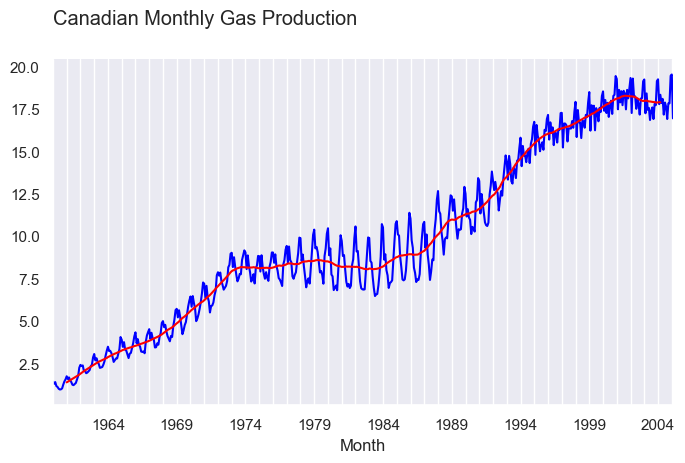

```python
fig, ax = plt.subplots()
can_gas["Volume"].plot(figsize=sizets, c="blue", ax= ax, label="Volume")
can_gas["mean_window_k"].plot(figsize=sizets, c="red", ax= ax,
label = f"Windowed volumen mean for {window_size} moths")
suptitle('Canadian Monthly Gas Production')
ax.grid(visible=True, which='Both', axis='x')
ax.grid(visible=False, which='Major', axis='y')
```

**Exercise 004**

You can play with the window size and see the effect it has in this plot. What happens with a 5 wide windo or an 80 wide one?

Why do you think we picked 24 as the intital value? Which is the *best* choice for window width?

It should be clear that regression methods can play a role in the answer to this question, and there are many possible methods to estimate a trend.

**Exercise 005**

Apply the above ideas to our `cherry_filled` dataset, until you are satisfied with the window width. What is the trend in recent years?

**Dealing with Seasonality**

The seasonal behavior of a time series can often be guessed from expert knowledge of the observed quantity and of the sampling frequency used in the time series. The [table in Section 2.1 of (Hyndman and Athanasopoulos 2021)](https://otexts.com/fpp3/tsibbles.html#the-seasonal-period) can be used as a guide for the relation between the tyoe of observations (yearly, monthly, weekly, daily, hourly) and the seasonal period that we can expect to find in our data.

For the canadian gas example we have mothly data. Therefore we expect a seasonal period of 12. Let us see if we can confirm it through EDA. We will plot a subseries spanning several years and we will plot a vertical dashed line every twelve months. Ignoring the effect of the trend, can you see the seasonal behavior?

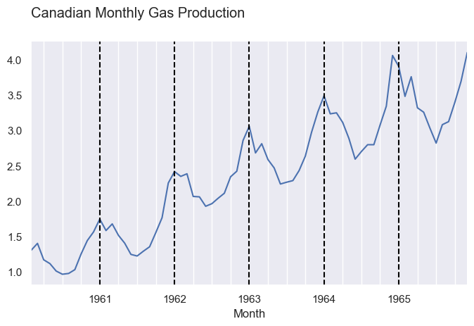

```python
ax = can_gas["Volume"][1:72].plot(figsize=sizets)
suptitle('Canadian Monthly Gas Production')
xcoords = ['1962-01-01', '1961-01-01','1963-01-01', '1964-01-01', '1965-01-01', '1966-01-01']
for xc in xcoords:
    plt.axvline(x=xc, color='black', linestyle='--')

ax.grid(visible=True, which='both', axis='x')
ax.grid(visible=False, which='Major', axis='y')
```

```python
# fig, ax = plt.subplots()
# plot_series(can_gas["Volume"], markers="_", ax=ax)
# ax.get_xticks()
```

**Seasonal Plots**

Once you have a candidate for the seasonal period , the EDA in the previous plot can be organized in a systematic way to obtain the so called **seasonal plots**. In order to plot them we will run an auxiliary code script that contains the plotting functions below.

```python
%run -i "Time_Series_Graphics.py"
```

The first plot stacks the seasonal periods on top of each other so that the trend is reflected in the vertical direction.

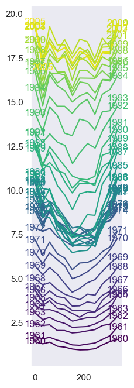

```python
this_fig_size = (2, 8)
ax = plot_seasonal(can_gas, 'Volume', labels='both', figsize=this_fig_size)
ax.grid()
```

```python
# fig, ax = plt.subplots()
# sm.graphics.tsa.month_plot(can_gas.Volume, ax=ax)
# ax.set(xlabel='Month', ylabel='Volume')
# ax.grid()
```

The following grid plot shows each individual seasonal period for the entire timespan of the dataset

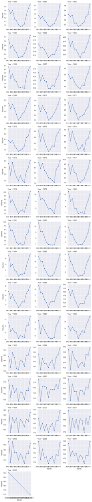

```python
g = sns.FacetGrid(can_gas.reset_index(names="Month"), col="Year",col_wrap=3, sharex=False, sharey=False)
g.map(sns.scatterplot, "Month", "Volume")
g.map(sns.lineplot, "Month", "Volume")
```

**Time Series Additive and Multiplicative Decomposition**

Given a time series $y_t$, an **additive decomposition** is a representation of the series as a sum of terms or **components**.

$y_{t} = T_{t} + S_{t} + R_t$

Here

- $T_t$ is the **trend term**
- $S_t$ is the **seasonal term**
- $R_t$ is called the **residual** term of the decomposition. It accounts for the remaining behavior of the time series not explained by trend or seasonality.

Such decompositions are provided by several Python libraries. The one we use here comes from `statmodels`:

```python
can_gas_decomp_add = seasonal_decompose(can_gas['Volume'], model='additive')
```

The individual components can be accessed as:

```python
can_gas_decomp_add.trend[0:20]
```

```
Month
1960-01-01         NaN
1960-02-01         NaN
1960-03-01         NaN
1960-04-01         NaN
1960-05-01         NaN
1960-06-01         NaN
1960-07-01    1.235442
1960-08-01    1.260108
1960-09-01    1.283125
1960-10-01    1.308975
1960-11-01    1.335417
1960-12-01    1.357254
1961-01-01    1.377792
1961-02-01    1.401633
1961-03-01    1.428192
1961-04-01    1.454279
1961-05-01    1.480362
1961-06-01    1.522617
1961-07-01    1.579392
1961-08-01    1.639237
Name: trend, dtype: float64
```

Note the perodicity in the seasonal component:

```python
can_gas_decomp_add.seasonal[0:24]
```

```
Month
1960-01-01    1.202323
1960-02-01    0.049430
1960-03-01    0.618550
1960-04-01   -0.055643
1960-05-01   -0.323980
1960-06-01   -0.952787
1960-07-01   -0.657013
1960-08-01   -0.622628
1960-09-01   -0.791312
1960-10-01    0.043161
1960-11-01    0.358891
1960-12-01    1.131007
1961-01-01    1.202323
1961-02-01    0.049430
1961-03-01    0.618550
1961-04-01   -0.055643
1961-05-01   -0.323980
1961-06-01   -0.952787
1961-07-01   -0.657013
1961-08-01   -0.622628
1961-09-01   -0.791312
1961-10-01    0.043161
1961-11-01    0.358891
1961-12-01    1.131007
Name: seasonal, dtype: float64
```

And we can get a nice graphical representation of the decomposition as follows:

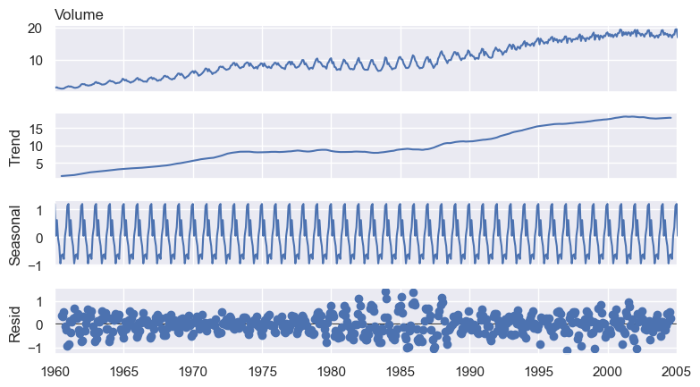

```python
plt.figure()
can_gas_decomp_add.plot()
plt.show()
```

Note here that the seasonal component is centered at 0.

**Time Series Multiplicative Decomposition**

An **multiplicative decomposition** is a representation of the series as a **product** of **components**.

$y_{t} = T_{t} \cdot S_{t} \cdot R_t$

We can aldo get multiplicative decompositions from Python libraries, in particular `statmodels`:

```python
can_gas_decomp_mult = seasonal_decompose(can_gas['Volume'], model='multiplicative')
```

And the corresponding visualization is:

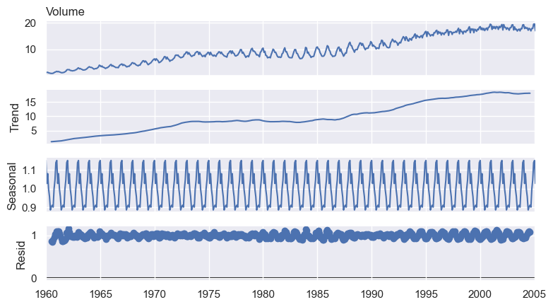

```python
plt.figure()
can_gas_decomp_mult.plot()
plt.show()
```

Note that the residual and seasonal components are centered in 1 now, instead of zero.

**Additive vs Multiplicative**

```python
PBS = pd.read_csv('tsdata/tsibbledata/PBS.csv', parse_dates=['Month'])

a10 = (
    PBS
    .query('ATC2 == "A10"')
    .groupby('Month', sort=False)
    .pipe(summarize, lambda x: dict(Cost = x.Cost.sum() / 1e6))
    .reset_index()
    .set_index('Month', drop=True)
)
a10
```

| Month | Cost |
| --- | --- |
| 1991-07-01 | 3.526591 |
| 1991-08-01 | 3.180891 |
| 1991-09-01 | 3.252221 |
| 1991-10-01 | 3.611003 |
| 1991-11-01 | 3.565869 |
| ... | ... |
| 2008-02-01 | 21.654285 |
| 2008-03-01 | 18.264945 |
| 2008-04-01 | 23.107677 |
| 2008-05-01 | 22.912510 |
| 2008-06-01 | 19.431740 |

204 rows × 1 columns

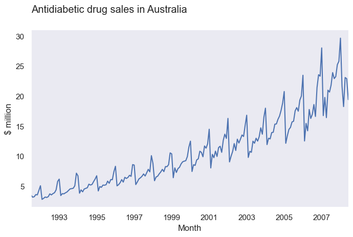

```python
ax = a10.Cost.plot(figsize=sizets)
suptitle('Antidiabetic drug sales in Australia')
ax.set(ylabel='$ million')
ax.grid()
```

```python
a10_decomp_mult = seasonal_decompose(a10, model='multiplicative')
```

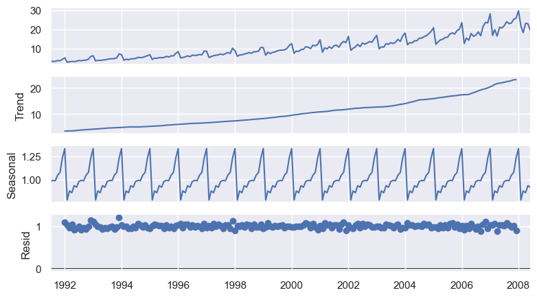

```python
plt.figure()
a10_decomp_mult.plot()
plt.show()
```

**In the Next Session**

We will discuss time series in the wider context of stochastic processes and we will meet out first forecasting models.

## References

Hyndman, R. J., and G. Athanasopoulos. 2021. *Forecasting: Principles and Practice*. OTexts. https://otexts.com/fpp3/.

J., Manu. 2022. *Modern Time Series Forecasting with Python*. Packt Publishing. https://www.packtpub.com/product/modern-time-series-forecasting-with-python/9781803246802.